# MAT3024 Regression Analysis Assignment

#### GROUP MEMBERS

Chong Kai Yuan (21081609)  
Ethan Lee Jia Hua (21089750)  
Daniel Chin Wei Jian (20095204)  
Darren Yap Yee Shern (21001235)  
Harreesh Dev Chandrasager (20083200)  
Nur’ Aliah Syamimi Binti Muhammad Sazali (21081765)

#### INTRODUCTION & PROBLEM STATEMENT

**Predicting Wine Quality Using Regression Analysis**

Consumers rely heavily on quality ratings when selecting wines. Accurate predictions of wine quality enable producers to better meet consumer expectations, resulting in higher satisfaction and repeat purchases **(Lockshin & Rhodus, 1993).** This study aims to identify and quantify the impact of different physicochemical properties on the quality ratings of white Vinho Verde wines.

**Determining Key Physicochemical Factors Influencing Wine Quality**

Our primary objective is to create a regression model that highlights the most significant factors contributing to wine quality. The analysis will focus on identifying the key physicochemical properties that influence wine quality and quantifying their impact. As such, our task will help winemakers optimize their production processes and improve the quality of their wines.

#### DATA PROCESSING

Load the use of all relevant packages used under this assignment

```r
library(car)
library(MASS)
library(dplyr)
library(olsrr)
library(leaps)
library(psych)
library(ggplot2)
library(pastecs)
library(corrplot)
library(tidyverse)
library(AICcmodavg)
library(ggThemeAssist)
library(rmdformats)
options(scipen=10)
```

Import dataset into R Studio

```r
Dataset<-read.csv("winequality-white.csv", sep =";")
str(Dataset)
```

```
## 'data.frame':    4898 obs. of  12 variables:
##  $ fixed.acidity       : num  7 6.3 8.1 7.2 7.2 8.1 6.2 7 6.3 8.1 ...
##  $ volatile.acidity    : num  0.27 0.3 0.28 0.23 0.23 0.28 0.32 0.27 0.3 0.22 ...
##  $ citric.acid         : num  0.36 0.34 0.4 0.32 0.32 0.4 0.16 0.36 0.34 0.43 ...
##  $ residual.sugar      : num  20.7 1.6 6.9 8.5 8.5 6.9 7 20.7 1.6 1.5 ...
##  $ chlorides           : num  0.045 0.049 0.05 0.058 0.058 0.05 0.045 0.045 0.049 0.044 ...
##  $ free.sulfur.dioxide : num  45 14 30 47 47 30 30 45 14 28 ...
##  $ total.sulfur.dioxide: num  170 132 97 186 186 97 136 170 132 129 ...
##  $ density             : num  1.001 0.994 0.995 0.996 0.996 ...
##  $ pH                  : num  3 3.3 3.26 3.19 3.19 3.26 3.18 3 3.3 3.22 ...
##  $ sulphates           : num  0.45 0.49 0.44 0.4 0.4 0.44 0.47 0.45 0.49 0.45 ...
##  $ alcohol             : num  8.8 9.5 10.1 9.9 9.9 10.1 9.6 8.8 9.5 11 ...
##  $ quality             : int  6 6 6 6 6 6 6 6 6 6 ...
```

**DATASET DESCRIPTION : WINE QUALITY DATASET**

[figure not shown]

Variables Involved under considered dataset:

1. Sulphates (g(potassium sulphate)/dm<sup>3</sup>)
2. Chlorides (g(sodium chloride)/dm<sup>3</sup>)
3. Volatile acidity (g(acetic acid)/dm<sup>3</sup>)
4. Fixed acidity (g(tartaric acid)/dm<sup>3</sup>)
5. Total sulfur dioxide (mg/dm<sup>3</sup>)
6. Free sulfur dioxide (mg/dm<sup>3</sup>)
7. Residual sugar (g/dm<sup>3</sup>)
8. Citric acid (g/dm<sup>3</sup>)
9. Density (g/cm<sup>3</sup>)
10. Alcohol (vol.%)
11. pH level
12. Quality

This Dataset consists of 4898 observations based on 12 variables

Data source: [Wine Quality Dataset](https://www.kaggle.com/datasets/yasserh/wine-quality-dataset)

#### DATA ANALYSIS

**DESCRIPTIVE STATISTICS (20%)**

```r
round(stat.desc(Dataset),2)
```

```
##              fixed.acidity volatile.acidity citric.acid residual.sugar
## nbr.val            4898.00          4898.00     4898.00        4898.00
## nbr.null              0.00             0.00       19.00           0.00
## nbr.na                0.00             0.00        0.00           0.00
## min                   3.80             0.08        0.00           0.60
## max                  14.20             1.10        1.66          65.80
## range                10.40             1.02        1.66          65.20
## sum               33574.75          1362.83     1636.87       31305.15
## median                6.80             0.26        0.32           5.20
## mean                  6.85             0.28        0.33           6.39
## SE.mean               0.01             0.00        0.00           0.07
## CI.mean.0.95          0.02             0.00        0.00           0.14
## var                   0.71             0.01        0.01          25.73
## std.dev               0.84             0.10        0.12           5.07
## coef.var              0.12             0.36        0.36           0.79
##              chlorides free.sulfur.dioxide total.sulfur.dioxide density
## nbr.val        4898.00             4898.00              4898.00 4898.00
## nbr.null          0.00                0.00                 0.00    0.00
## nbr.na            0.00                0.00                 0.00    0.00
## min               0.01                2.00                 9.00    0.99
## max               0.35              289.00               440.00    1.04
## range             0.34              287.00               431.00    0.05
## sum             224.19           172939.00            677690.50 4868.75
## median            0.04               34.00               134.00    0.99
## mean              0.05               35.31               138.36    0.99
## SE.mean           0.00                0.24                 0.61    0.00
## CI.mean.0.95      0.00                0.48                 1.19    0.00
## var               0.00              289.24              1806.09    0.00
## std.dev           0.02               17.01                42.50    0.00
## coef.var          0.48                0.48                 0.31    0.00
##                    pH sulphates  alcohol  quality
## nbr.val       4898.00   4898.00  4898.00  4898.00
## nbr.null         0.00      0.00     0.00     0.00
## nbr.na           0.00      0.00     0.00     0.00
## min              2.72      0.22     8.00     3.00
## max              3.82      1.08    14.20     9.00
## range            1.10      0.86     6.20     6.00
## sum          15616.13   2399.27 51498.88 28790.00
## median           3.18      0.47    10.40     6.00
## mean             3.19      0.49    10.51     5.88
## SE.mean          0.00      0.00     0.02     0.01
## CI.mean.0.95     0.00      0.00     0.03     0.02
## var              0.02      0.01     1.51     0.78
## std.dev          0.15      0.11     1.23     0.89
## coef.var         0.05      0.23     0.12     0.15
```

**VIZUALIZING THE DEPENDENT VARIABLE**

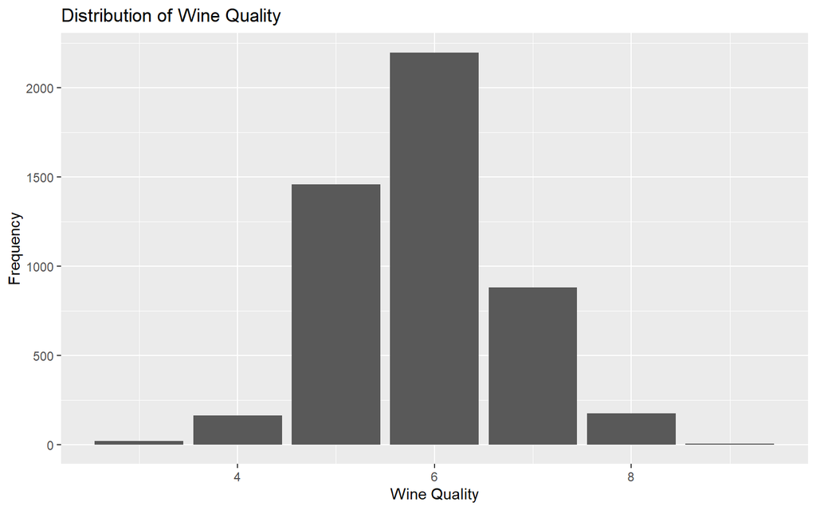

```r
ggplot(Dataset, aes(x = quality)) +
  geom_bar() +
  xlab("Wine Quality") +
  ylab("Frequency") +
  ggtitle("Distribution of Wine Quality")
```

**FITTING THE FULL MODEL**

Here, we observe the model using the entirety of the wine dataset in terms of its AIC, BIC, Residual standard error and its R<sup>2</sup>. Additionally, we investigate the whether each of the predictor variables appear to be statistically significant in predicting our dependent variable

```r
# fitting full model

full_model<-lm(quality~.,data=Dataset)
summary(full_model)

# extracting and finding relevant metrics

Residual_standard_error_full_model<-summary(full_model)$sigma
R_squared_full_model<-summary(full_model)$r.squared
full_model_AIC<-AIC(full_model)
full_model_BIC<-BIC(full_model)

# displaying results

table_1 <- data.frame(
  Metrics = c("AIC", "BIC", "R-squared", "Residual standard error"),
  full_model = c(full_model_AIC, full_model_BIC, R_squared_full_model, Residual_standard_error_full_model))

# formatting table

table_1$full_model <- format(table_1$full_model, digits = 5)

# displaying table

table_1
```

```
##
## Call:
## lm(formula = quality ~ ., data = Dataset)
##
## Residuals:
##     Min      1Q  Median      3Q     Max
## -3.8348 -0.4934 -0.0379  0.4637  3.1143
##
## Coefficients:
##                          Estimate   Std. Error t value Pr(>|t|)
## (Intercept)           150.1928425   18.8041772   7.987 1.71e-15 ***
## fixed.acidity           0.0655200    0.0208737   3.139  0.00171 **
## volatile.acidity       -1.8631771    0.1137933 -16.373  < 2e-16 ***
## citric.acid             0.0220902    0.0957696   0.231  0.81759
## residual.sugar          0.0814828    0.0075273  10.825  < 2e-16 ***
## chlorides              -0.2472765    0.5465423  -0.452  0.65097
## free.sulfur.dioxide     0.0037328    0.0008441   4.422 9.99e-06 ***
## total.sulfur.dioxide   -0.0002857    0.0003781  -0.756  0.44979
## density              -150.2841806   19.0745080  -7.879 4.04e-15 ***
## pH                      0.6863437    0.1053791   6.513 8.10e-11 ***
## sulphates               0.6314765    0.1003856   6.291 3.44e-10 ***
## alcohol                 0.1934757    0.0242214   7.988 1.70e-15 ***
## ---
## Signif. codes:  0 '***' 0.001 '**' 0.01 '*' 0.05 '.' 0.1 ' ' 1
##
## Residual standard error: 0.7514 on 4886 degrees of freedom
## Multiple R-squared:  0.2819, Adjusted R-squared:  0.2803
## F-statistic: 174.3 on 11 and 4886 DF,  p-value: < 2.2e-16
##
##                   Metrics  full_model
## 1                     AIC 11113.48027
## 2                     BIC 11197.93584
## 3               R-squared     0.28187
## 4 Residual standard error     0.75136
```

**OBSERVATION OF FULL MODEL**

From the output of the summary of the dataset, we can observe that three predictor variables can be highlighted and appears to not be statistically significant. Those variables being:

1. Citric Acid (g/dm<sup>3</sup>)
2. Total sulfur dioxide (mg/dm<sup>3</sup>)
3. Chlorides (g(sodium chloride)/dm<sup>3</sup>)

From here we can start making the hypothesis that when performing the variable selection process to find our “best” regression model, it is more likely than not that one or several of these variables will likely not be included under the fitted model.

**INVESTIGATING PROBLEMATIC DATA POINTS**

Before we proceed into building our regression models, it is crucial to ensure the reliability and accuracy of our current dataset by investigating any potentially problematic observation points. In here, we decided to take into account the following metrics:

1. Leverage (*h<sub>ii</sub>*) - may affect regression coefficients
2. Cook’s Distance (*D<sub>i</sub>*) - to observe influential points
3. Studentized Residuals (*r<sub>i</sub>*) - to observe potential outliers

Observation points that exceed tolerated thresholds in these diagnostic measures will then be considered as problematic. Consequently, an updated full model will be created after removing these problematic points, ensuring a more robust and accurate predictive model.

**VISUALIZING MODEL USING DIAGNOSTIC PLOTS**

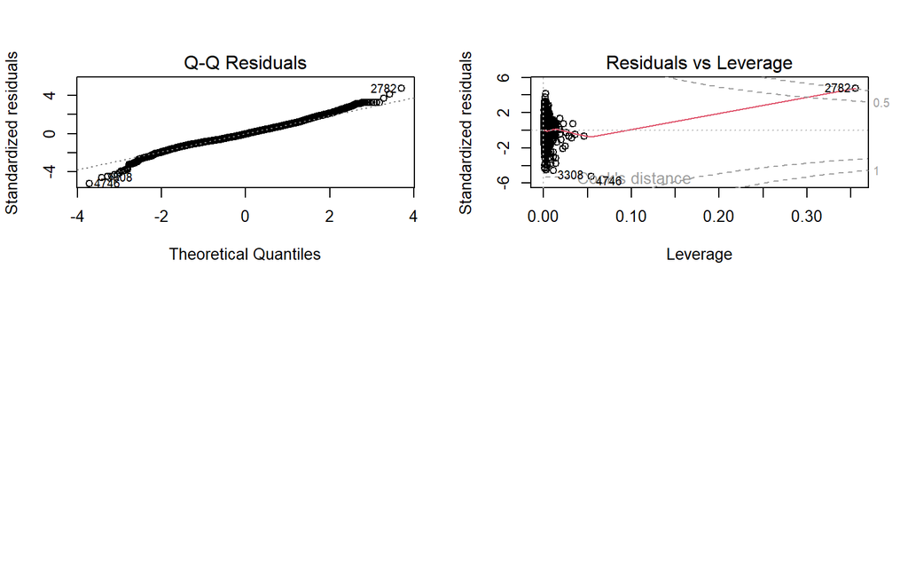

```r
par(mfrow=c(2,2))
plot(full_model,which=2) # QQ Residuals
plot(full_model,which=5) # Residuals vs Leverage
```

**INTERPRETATION**

QQ Residuals: The lines curve at the ends, implying that under the full model, the residuals have heavier tails than a normal distribution, this acts as an indicator for the presence of outliers in the dataset.

Residuals vs Leverage: Presence of observations clearly outside the Cook’s distance contour lines, indicating presence of influential points within the Dataset.

Now, we will make use of the following thresholds in deciding which observations points are considered problematic which should be removed from our dataset.

Table 1: Diagnostics values and their associated thresholds

| Diagnostic Value Tested | Tolerated Threshold |
| --- | --- |
| Studentized Residuals $(ri)$ | $< 3$ |
| Cook’s Distance $(Di)$ | $< 4/n$ |
| Leverage $(hii)$ | $< 2p/n$ |

Under different applications, the threshold for the cook’s distance may also be $< 1$, however, we decided to use the threshold of $< 4/n$ instead being that in this way, the number of observations in the dataset is taken into account when performing our investigation of problematic observation points.

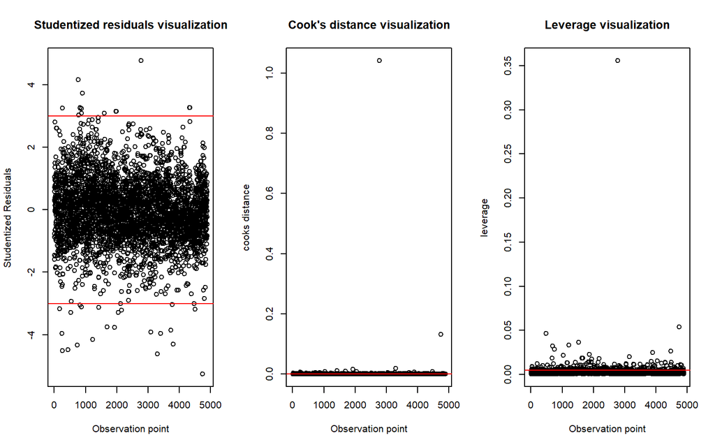

```r
# studentized residuals

studentized_residuals_full_model<-studres(full_model)

# cooks distance

cd_full_model<-cooks.distance(full_model)

# leverage

hat_values_full_model<-hatvalues(full_model)

# plot for visualization

par(mfrow=c(1,3))

plot(studentized_residuals_full_model, main="Studentized residuals visualization", ylab="Studentized Residuals",xlab="Observation point")
abline(h=3,col="red")
abline(h=-3,col="red")

plot(cd_full_model, main="Cook's distance visualization", ylab="cooks distance",xlab="Observation point")
abline(h = 4/(nrow(Dataset)), col = "red")

plot(hat_values_full_model, main="Leverage visualization",ylab="leverage", xlab="Observation point")
abline(h= 2 * (length(full_model$coefficients)) / nrow(Dataset),col ="red")
```

```r
# indicate all flagged points that need to be removed

high_studentized_residual_points<-which(studentized_residuals_full_model>(abs(3)))
high_leverage_points<-which(hat_values_full_model>(2*(length(full_model$coefficients))/nrow(Dataset)))
high_cooks_distance_points<-which(cd_full_model>(4/nrow(Dataset)))

all_potential_issues<-unique(c(high_studentized_residual_points,high_leverage_points,high_cooks_distance_points))

# create updated full model

updated_Dataset<-Dataset[-all_potential_issues, ]
```

**FITTING UPDATED FULL MODEL**

```r
# fitting updated full model

updated_full_model<-lm(quality~.,data=updated_Dataset)
str(updated_Dataset)
summary(updated_full_model)

# extracting and finding relevant metrics

Residual_standard_error_updated_full_model<-summary(updated_full_model)$sigma
R_squared_updated_full_model<-summary(updated_full_model)$r.squared
updated_full_model_AIC<-AIC(updated_full_model)
updated_full_model_BIC<-BIC(updated_full_model)

# displaying results

table_2 <- data.frame(
  Metrics = c("AIC", "BIC", "R-squared", "Residual standard error"),
  full_model = c(full_model_AIC, full_model_BIC, R_squared_full_model, Residual_standard_error_full_model),
  updated_full_model = c(updated_full_model_AIC, updated_full_model_BIC, R_squared_updated_full_model, Residual_standard_error_updated_full_model))

# formatting table

table_2$full_model <- format(table_2$full_model, digits = 5)
table_2$updated_full_model <- format(table_2$updated_full_model, digits = 5)

# display updated table

table_2
```

```
## 'data.frame':    4470 obs. of  12 variables:
##  $ fixed.acidity       : num  7 6.3 8.1 7.2 7.2 8.1 6.2 7 6.3 8.1 ...
##  $ volatile.acidity    : num  0.27 0.3 0.28 0.23 0.23 0.28 0.32 0.27 0.3 0.22 ...
##  $ citric.acid         : num  0.36 0.34 0.4 0.32 0.32 0.4 0.16 0.36 0.34 0.43 ...
##  $ residual.sugar      : num  20.7 1.6 6.9 8.5 8.5 6.9 7 20.7 1.6 1.5 ...
##  $ chlorides           : num  0.045 0.049 0.05 0.058 0.058 0.05 0.045 0.045 0.049 0.044 ...
##  $ free.sulfur.dioxide : num  45 14 30 47 47 30 30 45 14 28 ...
##  $ total.sulfur.dioxide: num  170 132 97 186 186 97 136 170 132 129 ...
##  $ density             : num  1.001 0.994 0.995 0.996 0.996 ...
##  $ pH                  : num  3 3.3 3.26 3.19 3.19 3.26 3.18 3 3.3 3.22 ...
##  $ sulphates           : num  0.45 0.49 0.44 0.4 0.4 0.44 0.47 0.45 0.49 0.45 ...
##  $ alcohol             : num  8.8 9.5 10.1 9.9 9.9 10.1 9.6 8.8 9.5 11 ...
##  $ quality             : int  6 6 6 6 6 6 6 6 6 6 ...
##
## Call:
## lm(formula = quality ~ ., data = updated_Dataset)
##
## Residuals:
##      Min       1Q   Median       3Q      Max
## -1.98635 -0.47870 -0.04531  0.44472  2.18522
##
## Coefficients:
##                          Estimate   Std. Error t value Pr(>|t|)
## (Intercept)           178.1641778   23.0787764   7.720 1.43e-14 ***
## fixed.acidity           0.1110092    0.0228811   4.852 1.27e-06 ***
## volatile.acidity       -1.7635996    0.1185578 -14.875  < 2e-16 ***
## citric.acid             0.0642252    0.0982086   0.654  0.51317
## residual.sugar          0.0871529    0.0085888  10.147  < 2e-16 ***
## chlorides              -2.9133938    0.9265630  -3.144  0.00168 **
## free.sulfur.dioxide     0.0040293    0.0008528   4.725 2.38e-06 ***
## total.sulfur.dioxide   -0.0003297    0.0003679  -0.896  0.37022
## density              -178.8304217   23.3912821  -7.645 2.54e-14 ***
## pH                      0.8673713    0.1077638   8.049 1.06e-15 ***
## sulphates               0.6937781    0.0996787   6.960 3.89e-12 ***
## alcohol                 0.1474818    0.0287033   5.138 2.89e-07 ***
## ---
## Signif. codes:  0 '***' 0.001 '**' 0.01 '*' 0.05 '.' 0.1 ' ' 1
##
## Residual standard error: 0.6528 on 4458 degrees of freedom
## Multiple R-squared:  0.3274, Adjusted R-squared:  0.3258
## F-statistic: 197.3 on 11 and 4458 DF,  p-value: < 2.2e-16
##
##                   Metrics  full_model updated_full_model
## 1                     AIC 11113.48027         8886.90538
## 2                     BIC 11197.93584         8970.17224
## 3               R-squared     0.28187            0.32741
## 4 Residual standard error     0.75136            0.65283
```

**INTERPRETATION**

By inspection, the new dataset has 4470 observations which shows that a total of 428 observation points have been removed. At first glance, we can see that after removing the problematic points, the updated model evidently exhibit better model properties. It has a lower AIC and BIC value, which indicates that the model has an improved fit and better performance relative to the previous model. Additionally, it has a smaller residual standard error, which shows that the predictions of the model are more accurate while having less variability. The R-squared value is also higher, indicating that a greater proportion of the variance in the dependent variable is explained by the independent variables in the model which is ideal for a regression model.

Additionally, from the output of the summary of the updated dataset, we can see that now only two of the predictor variables appears to not be statistically significant. Those variables being:

1. Citric Acid (g/dm<sup>3</sup>)
2. Total sulfur dioxide (mg/dm<sup>3</sup>)

This strengthens our previous assumption that these variables have a higher chance of being excluded from the “best” regression model later when performing the variable selection process.

**INSPECTING UPDATED MODEL USING DIAGNOSTIC PLOTS**

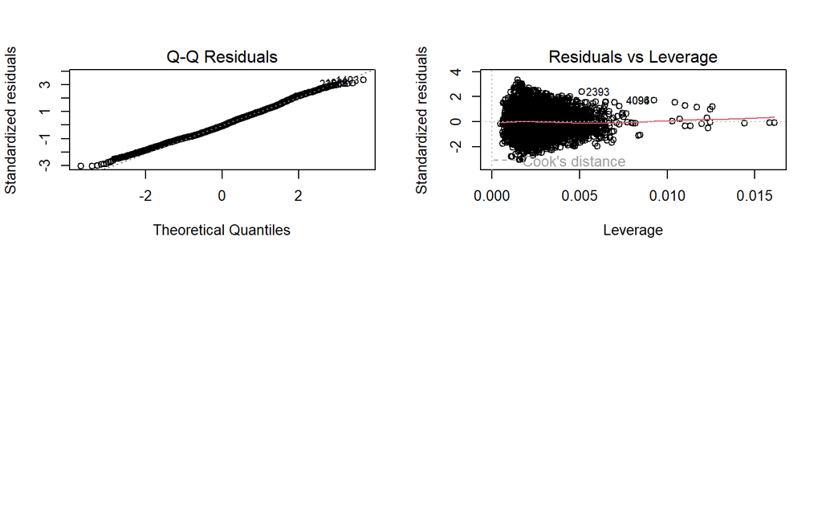

```r
par(mfrow=c(2,2))
plot(updated_full_model,which=2) # QQ Residuals
plot(updated_full_model,which=5) # Residuals vs Leverage
```

**INTERPRETATION**

QQ Residuals: Seem to follow along the 45 degree reference line. This shows that under the new model, the residuals are better suited by assuming a normal distribution, which is an ideal condition for regression analysis.

Residuals vs Leverage: There appear to be no points that lie outside the designated Cook’s distance contour lines, indicating that there are no overly influential points under the new model.

#### FINDING “BEST” REGRESSION MODEL

**INVESTIGATING CORRELATION**

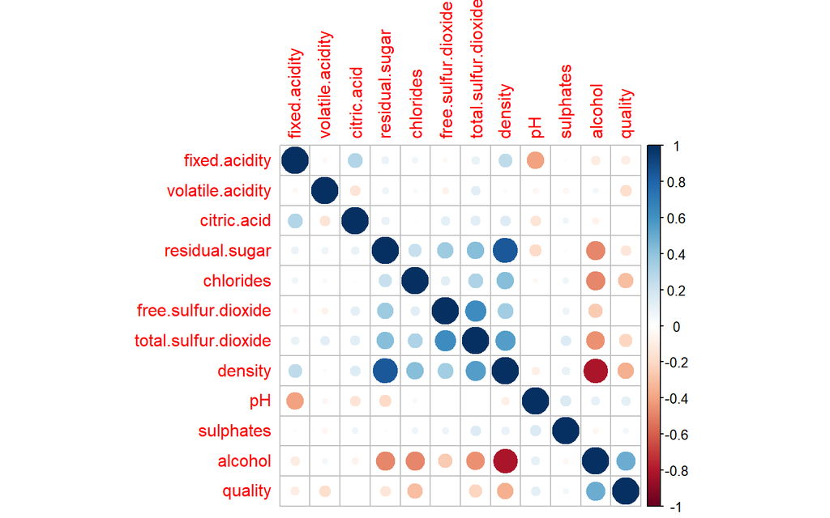

```
##                      fixed.acidity volatile.acidity citric.acid residual.sugar
## fixed.acidity                 1.00            -0.04        0.29           0.08
## volatile.acidity             -0.04             1.00       -0.15           0.07
## citric.acid                   0.29            -0.15        1.00           0.09
## residual.sugar                0.08             0.07        0.09           1.00
## chlorides                     0.06             0.03        0.01           0.22
## free.sulfur.dioxide          -0.04            -0.07        0.11           0.35
## total.sulfur.dioxide          0.09             0.12        0.13           0.42
## density                       0.25             0.02        0.15           0.84
## pH                           -0.41            -0.05       -0.15          -0.20
## sulphates                    -0.02            -0.05        0.06          -0.02
## alcohol                      -0.11             0.05       -0.07          -0.49
## quality                      -0.10            -0.18        0.00          -0.14
##                      chlorides free.sulfur.dioxide total.sulfur.dioxide density
## fixed.acidity             0.06               -0.04                 0.09    0.25
## volatile.acidity          0.03               -0.07                 0.12    0.02
## citric.acid               0.01                0.11                 0.13    0.15
## residual.sugar            0.22                0.35                 0.42    0.84
## chlorides                 1.00                0.12                 0.30    0.42
## free.sulfur.dioxide       0.12                1.00                 0.62    0.34
## total.sulfur.dioxide      0.30                0.62                 1.00    0.55
## density                   0.42                0.34                 0.55    1.00
## pH                       -0.04               -0.01                 0.00   -0.09
## sulphates                 0.06                0.07                 0.14    0.09
## alcohol                  -0.49               -0.26                -0.46   -0.82
## quality                  -0.31               -0.01                -0.22   -0.36
##                         pH sulphates alcohol quality
## fixed.acidity        -0.41     -0.02   -0.11   -0.10
## volatile.acidity     -0.05     -0.05    0.05   -0.18
## citric.acid          -0.15      0.06   -0.07    0.00
## residual.sugar       -0.20     -0.02   -0.49   -0.14
## chlorides            -0.04      0.06   -0.49   -0.31
## free.sulfur.dioxide  -0.01      0.07   -0.26   -0.01
## total.sulfur.dioxide  0.00      0.14   -0.46   -0.22
## density              -0.09      0.09   -0.82   -0.36
## pH                    1.00      0.16    0.10    0.11
## sulphates             0.16      1.00   -0.05    0.05
## alcohol               0.10     -0.05    1.00    0.49
## quality               0.11      0.05    0.49    1.00
```

```r
# finding correlation values between all variables

correlation_matrix<-round(cor(updated_Dataset),2)
correlation_matrix

# visualize correlation in a diagram

corrplot::corrplot(correlation_matrix)
```

**INTERPRETATION**

We can separate the interpretation into 2 parts:

1. Dependent variable with the regressor variables:

By referring to the last row under the correlation plot, we can identify the correlation between the dependent variable against all 11 other independent variables under this dataset. We notice out of all variables, there are two variables that stand out, that being alcohol (vol.%) and also density (g/cm<sup>3</sup>). The exact correlation values are 0.49 and -0.36 respectively and a higher value indicates a stronger linear relationship and the potential to be a valuable predictor of y.

2. Regressor variables with each other (multicollinearity)

- Alcohol & Density : correlation value of -0.82
- Density & Residual sugar : correlation value of 0.84

Both are relatively high in terms of their correlation, thus further investigation into their multicollinearity properties should be investigated using other diagnostics. In this case, we will make use of the “variance inflation factor” values to see how much the variance of the regression coefficients are inflated due to multicollinearity issues. Note that in our case, we will use the threshold as VIF values $> 10$ being considered to have high multicollinearity problems.

**INVESTIGATING MULTICOLLINEARITY FOR FULL MODEL**

```r
# investigating multicollinearity under model

vif_updated_full_model<-vif(updated_full_model)
vif_updated_full_model

# pinpoint key predictors with high vif values

vif_alcohol_full_model <- vif_updated_full_model['alcohol']
vif_density_full_model <- vif_updated_full_model['density']
vif_residual_sugar_full_model <- vif_updated_full_model['residual.sugar']

# display table with predictors showing high vif values

table_3 <- data.frame(
vif_full_model = c(vif_alcohol_full_model, vif_residual_sugar_full_model, vif_density_full_model ))

table_3
```

```
##        fixed.acidity     volatile.acidity          citric.acid
##             3.502695             1.129971             1.157082
##       residual.sugar            chlorides  free.sulfur.dioxide
##            18.945214             1.395005             1.836549
## total.sulfur.dioxide              density                   pH
##             2.373692            47.964676             2.604507
##            sulphates              alcohol
##             1.168026            12.698705
##                vif_full_model
## alcohol              12.69870
## residual.sugar       18.94521
## density              47.96468
```

**INTERPRETATION**

Under the updated full model, these three variables exhibit high multicollinearity indications. Thus when building our regression models later, we will need to take into account these values and make appropriate adjustments if necessary.

**FITTING SIMPLE LINEAR MODEL**

With the updated dataset, we are now ready to start finding our “best” regression model. We will employ the use of a forward step procedure where we start with including one regressor variable in our model, and work our way up towards the best regression model by adding one regressor variable at a time.

In order to determine the first variable that should be included under the simple linear regression model, we will make use of the variable with the highest correlation value to our dependent variable, i.e. Alcohol (vol.%). Note that from here on out, “best_model_x” will refer to a the fitted model in respect to “x” number of variables, for example best_model_1 refers to 1 predictor being fitted in the model, or basically the best simple linear regression model.

```r
# fitting the "best" simple linear model

best_model_1<-lm(quality~alcohol,data = updated_Dataset)
summary(best_model_1)

# extracting and finding relevant metrics

Residual_standard_error_best_model_1<-summary(best_model_1)$sigma
R_squared__best_model_1<-summary(best_model_1)$r.squared
best_model_1_AIC<-AIC(best_model_1)
best_model_1_BIC<-BIC(best_model_1)

# displaying results

table_4 <- data.frame(
  Metrics = c("AIC", "BIC", "R-squared", "Residual standard error"),
  updated_full_model = c(updated_full_model_AIC, updated_full_model_BIC, R_squared_updated_full_model, Residual_standard_error_updated_full_model),
  best_model_1 = c(best_model_1_AIC, best_model_1_BIC, R_squared__best_model_1, Residual_standard_error_best_model_1))

# formatting table

table_4$best_model_1 <- format(table_4$best_model_1, digits = 5)
table_4$updated_full_model <- format(table_4$updated_full_model, digits = 5)

# display table of simple model and full model

table_4
```

```
##
## Call:
## lm(formula = quality ~ alcohol, data = updated_Dataset)
##
## Residuals:
##      Min       1Q   Median       3Q      Max
## -2.20806 -0.52864 -0.01572  0.46514  2.14457
##
## Coefficients:
##             Estimate Std. Error t value Pr(>|t|)
## (Intercept) 2.521459   0.090578   27.84   <2e-16 ***
## alcohol     0.320574   0.008558   37.46   <2e-16 ***
## ---
## Signif. codes:  0 '***' 0.001 '**' 0.01 '*' 0.05 '.' 0.1 ' ' 1
##
## Residual standard error: 0.6936 on 4468 degrees of freedom
## Multiple R-squared:  0.239,  Adjusted R-squared:  0.2388
## F-statistic:  1403 on 1 and 4468 DF,  p-value: < 2.2e-16
##
##                   Metrics updated_full_model best_model_1
## 1                     AIC         8886.90538   9419.08213
## 2                     BIC         8970.17224   9438.29757
## 3               R-squared            0.32741      0.23898
## 4 Residual standard error            0.65283      0.69364
```

**INTERPRETATION**

When comparing the metrics above with the simple linear model against the new full model, it is apparent that the simple linear model have values that are less ideal, such as a higher AIC and Residual standard error. However, this is to be expected as only one regressor has been added, in theory, as we add more explanatory variables, the metrics will eventually get more and more ideal unlike it reaches its optimum value stance where we can conclude the best model has been found.

**FITTING MULTIPLE LINEAR MODEL**

To decide on the next variables added, we decided to see which of the remaining regressor variables when added to the current model has the best statistical significance. Then by setting our stopping criterion based on a p value of 0.05, any variables when added to the model results in a p value greater than 0.05 will be deemed as non helpful.

```r
cortable = as.data.frame(cor(updated_Dataset))
cortablefiltered = subset(cortable, select = quality)
numbering = seq(12)
names = names(cortable)

data1 = data.frame(cortablefiltered, numbering, names)
data1 = data1[-12,]
data1$quality = abs(data1$quality)

pairs = c(NULL)
naming = names[-12]
naming = naming[-11]
nametest = naming

a = 12
b= 10

for (i in 1:a) {
  pvalue = c(NULL)
  AIC = c(NULL)
  count = c(NULL)
  stop = FALSE

  framefull = data1 %>% arrange(desc(quality))
  pairs[1] = framefull[1,3]
  cat("\nquality ~", pairs[i], "+ \n")

  for (j in 1:b) {
    formula = as.formula(paste("quality ~",pairs[i]," + ", nametest[j]))
    pvalue[j] = (summary(lm(formula, data = updated_Dataset))$coefficients)[i+2,4]
    AIC[j] = summary(glm(formula, data = updated_Dataset))$aic
    cat("\n\n")
    print(summary(lm(formula, data = updated_Dataset))$coefficients)
    count[j] = j
  }

  framefull2 = data.frame(pvalue, nametest, count)
  framefull2 = framefull2 %>% arrange(pvalue)
  nametest = nametest[-framefull2[1,3]]

  pairs[i+1] = paste(c(pairs[i], framefull2[1,2]), collapse = " + ")
  b = b - 1
  cat("\n", i," iteration done\n")

  cat("\nCurrent AIC: ", summary(glm(as.formula(paste("quality ~",pairs[i])), data = updated_Dataset))$aic, "\n\n")

  print(AIC)

  cat("\nP-values for each of next variables\n")
  print(pvalue)
  print("==========================================================")

  if (pvalue[framefull2[1,3]]>0.05){
    stop = TRUE
    formula2 = paste("quality ~", pairs[i])
    print(summary(glm(formula2, data = updated_Dataset)))
    break
  }
  if (stop){break}
}
```

```
##
## quality ~ alcohol +
##
##
##                  Estimate  Std. Error   t value      Pr(>|t|)
## (Intercept)    2.89341627 0.134079289 21.579890  2.489220e-98
## alcohol        0.31711142 0.008595353 36.893358 2.484199e-260
## fixed.acidity -0.04902708 0.013046307 -3.757928  1.735128e-04
##
##
##                    Estimate Std. Error   t value      Pr(>|t|)
## (Intercept)       2.9531655 0.09196732  32.11103 9.602901e-204
## alcohol           0.3278254 0.00832984  39.35554 4.175346e-291
## volatile.acidity -1.8709469 0.11534011 -16.22113  1.531971e-57
##
##
##              Estimate  Std. Error   t value      Pr(>|t|)
## (Intercept) 2.4312823 0.098370455 24.715575 1.617611e-126
## alcohol     0.3220096 0.008575948 37.547984 2.053794e-268
## citric.acid 0.2278051 0.097206895  2.343508  1.914697e-02
##
##
##                  Estimate  Std. Error   t value      Pr(>|t|)
## (Intercept)    1.96701077 0.111189405 17.690631  9.646230e-68
## alcohol        0.36095935 0.009738901 37.063664 1.993538e-262
## residual.sugar 0.02020446 0.002385842  8.468485  3.331427e-17
##
##
##               Estimate Std. Error   t value      Pr(>|t|)
## (Intercept)  3.0686182 0.12840453 23.898053 6.973219e-119
## alcohol      0.2920822 0.00976276 29.917999 2.035546e-179
## chlorides   -5.6945346 0.95083910 -5.988957  2.277688e-09
##
##
##                       Estimate   Std. Error  t value      Pr(>|t|)
## (Intercept)         2.06969415 0.1019149214 20.30806  8.978000e-88
## alcohol             0.34208060 0.0087838140 38.94443 6.735226e-286
## free.sulfur.dioxide 0.00641216 0.0006862682  9.34352  1.433473e-20
##
##
```

[output cut: 567 more lines]

```
## pH                     0.870439    0.106591   8.166 4.11e-16 ***
## density             -183.016739   22.401078  -8.170 3.98e-16 ***
## sulphates              0.693724    0.099592   6.966 3.75e-12 ***
## fixed.acidity          0.114772    0.022615   5.075 4.03e-07 ***
## chlorides             -2.976533    0.924643  -3.219   0.0013 **
## ---
## Signif. codes:  0 '***' 0.001 '**' 0.01 '*' 0.05 '.' 0.1 ' ' 1
##
## (Dispersion parameter for gaussian family taken to be 0.4261068)
##
##     Null deviance: 2824.8  on 4469  degrees of freedom
## Residual deviance: 1900.4  on 4460  degrees of freedom
## AIC: 8884.1
##
## Number of Fisher Scoring iterations: 2
```

**INTERPRETATION**

By inspection, we can conclude that the our current best fitted model consists of the following variables in the specified order:

1. Alcohol (vol.%)
2. Volatile acidity (g(acetic acid)/dm<sup>3</sup>)
3. Residual sugar (g/dm<sup>3</sup>)
4. Free sulfur dioxide (mg/dm<sup>3</sup>)
5. pH level
6. Density (g/cm<sup>3</sup>)
7. Sulphates (g(potassium sulphate)/dm<sup>3</sup>)
8. Fixed acidity (g(tartaric acid)/dm<sup>3</sup>)
9. Chlorides (g(sodium chloride)/dm<sup>3</sup>)

For further investigation and verification, we will also see how the other values (AIC, BIC, R-squared, Residual standard error) change as each new variable is fitted, if it is consistent with our findings, we should observe a trend where each of the values become more ideal with every variable included at each step.

```r
# fitting each of the models as best_model_x

# Create an empty list to store the models

best_models <- list()

# Loop through each element in pairs

for (i in 1:9) {
formula <- as.formula(paste("quality ~", pairs[i]))
best_models[[i]] <- lm(formula, data = updated_Dataset)

assign(paste0("best_model_", i), best_models[[i]])
}
```

```r
# finding the relevant values for each of the models

model_names <- paste0("best_model_", 1:9)

# Loop through each model

for (i in 1:9) {
model <- get(model_names[i])

assign(paste0("Residual_standard_error_", model_names[i]), summary(model)$sigma)
assign(paste0("R_squared_", model_names[i]), summary(model)$r.squared)
assign(paste0(model_names[i], "_AIC"), AIC(model))
assign(paste0(model_names[i], "_BIC"), BIC(model))}

table_5 <- data.frame(
  Metrics = c("AIC", "BIC", "R-squared", "Residual standard error"))

# Loop through each model to extract metrics and store them in the data frame

for (i in 1:9) {
model <- get(model_names[i])

aic_value <- AIC(model)
bic_value <- BIC(model)
r_squared_value <- summary(model)$r.squared
residual_standard_error <- summary(model)$sigma

table_5[paste0("best_model_", i)] <- c(aic_value, bic_value, r_squared_value, residual_standard_error)}

# formatting the table

for (i in 1:9) {
  column_name <- paste0("best_model_", i)
  table_5[[column_name]] <- format(table_5[[column_name]], digits = 5)}

# displaying the table

table_5
```

```
##                   Metrics best_model_1 best_model_2 best_model_3 best_model_4
## 1                     AIC   9419.08213   9165.24346   9053.38678   9020.42385
## 2                     BIC   9438.29757   9190.86403   9085.41250   9058.85471
## 3               R-squared      0.23898      0.28131      0.29939      0.30485
## 4 Residual standard error      0.69364      0.67415      0.66569      0.66317
##   best_model_5 best_model_6 best_model_7 best_model_8 best_model_9
## 1   8992.50376   8955.70723   8922.89163   8892.47115   8884.09726
## 2   9037.33977   9006.94838   8980.53793   8956.52259   8954.55384
## 3      0.30948      0.31545      0.32076      0.32567      0.32723
## 4      0.66103      0.65824      0.65575      0.65345      0.65277
```

**INTERPRETATION**

We can observe that for every new variable added, the metric values become more ideal for every model until best_model_9. As a safety measure to indicate that we shouldn’t add the remaining variables, we can also investigate how the metric values change if we add citric acid or total sulfur dioxide to the current model

```r
# fitting model including citric acid

model_10_citric_acid<-lm(quality~alcohol + volatile.acidity + residual.sugar + free.sulfur.dioxide + pH + density + sulphates + fixed.acidity + chlorides + citric.acid,data=updated_Dataset)

Residual_standard_error_model_10_citric_acid<-summary(model_10_citric_acid)$sigma
R_squared_model_10_citric_acid<-summary(model_10_citric_acid)$r.squared
model_10_citric_acid_AIC<-AIC(model_10_citric_acid)
model_10_citric_acid_BIC<-BIC(model_10_citric_acid)

# fitting model including total_sulfur_dioxide

model_10_total_sulfur_dioxide<-lm(quality~alcohol + volatile.acidity + residual.sugar + free.sulfur.dioxide + pH + density + sulphates + fixed.acidity + chlorides + total.sulfur.dioxide,data=updated_Dataset)

Residual_standard_error_model_10_total_sulfur_dioxide<-summary(model_10_total_sulfur_dioxide)$sigma
R_squared_model_10_total_sulfur_dioxide<-summary(model_10_total_sulfur_dioxide)$r.squared
model_10_total_sulfur_dioxide_AIC<-AIC(model_10_total_sulfur_dioxide)
model_10_total_sulfur_dioxide_BIC<-BIC(model_10_total_sulfur_dioxide)

# construct comparison table

table_6 <- data.frame(
  Metrics = c("AIC", "BIC", "R-squared", "Residual standard error"),
  best_model_9 = c(best_model_9_AIC, best_model_9_BIC, R_squared_best_model_9, Residual_standard_error_best_model_9),
  model_10_citric_acid = c(model_10_citric_acid_AIC, model_10_citric_acid_BIC, R_squared_model_10_citric_acid, Residual_standard_error_model_10_citric_acid),
  model_10_total_sulfur_dioxide = c(model_10_total_sulfur_dioxide_AIC, model_10_total_sulfur_dioxide_BIC, R_squared_model_10_total_sulfur_dioxide, Residual_standard_error_model_10_total_sulfur_dioxide)
  )

# formatting table

table_6$best_model_9 <- format(table_6$best_model_9, digits = 5)
table_6$model_10_citric_acid <- format(table_6$model_10_citric_acid, digits = 5)
table_6$model_10_total_sulfur_dioxide <- format(table_6$model_10_total_sulfur_dioxide, digits = 5)

# display table

table_6
```

```
##                   Metrics best_model_9 model_10_citric_acid
## 1                     AIC   8884.09726           8885.71056
## 2                     BIC   8954.55384           8962.57228
## 3               R-squared      0.32723              0.32729
## 4 Residual standard error      0.65277              0.65281
##   model_10_total_sulfur_dioxide
## 1                    8885.33418
## 2                    8962.19590
## 3                       0.32735
## 4                       0.65279
```

**INTERPRETATION**

By inspection between the model with 9 variables in comparison to the models with 10 variables, the model with 9 predictors is preferable over the models with 10 predictors despite the latter models having a slightly higher R-squared value. The model with 9 predictors exhibits lower AIC and BIC values, indicating better model performance and a more parsimonious fit. Additionally, the residual standard error is lower in the model with 9 predictors, suggesting better precision in its predictions. Moreover, it is crucial to note that the additional variable in the 10-predictor model is not statistically significant, further reinforcing that the 9-predictor model is more reliable and efficient.

**CHECKING MALLOWS** **Cp**

```r
# checking Mallows Cp for the current best model fitted

ols_best_model_9<-ols_mallows_cp(best_model_9,updated_full_model)
ols_best_model_9
```

```
## [1] 9.18884
```

**INTERPRETATION**

Under the model, we can observe that the Mallows $Cp$ value of 9.18884 is relatively close to $k+1=p=10$ which is the ideal value; indicating that the model is neither underfitting nor overfitting.

**REINVESTIGATING MULTICOLLINEARITY PROPERTIES**

Despite all the metrics pointing towards the conclusion that we have fitted the best model, it is also essential to consider multicollinearity in addition to traditional model evaluation metrics such as R-squared, AIC, BIC, and residual standard error. Hence we need to evaluate the presence of multicollinear issues for each model starting from the model including two regressor variables and so forth. Again, we will make use of the VIF values to investigate multicollinearity.

```r
# seeing vif for each model

vif(best_model_2)
vif(best_model_3)
vif(best_model_4)
vif(best_model_5)
vif(best_model_6)
```

```
##          alcohol volatile.acidity
##         1.002888         1.002888
##          alcohol volatile.acidity   residual.sugar
##         1.329738         1.016578         1.333360
##             alcohol    volatile.acidity      residual.sugar free.sulfur.dioxide
##            1.343023            1.026343            1.443502            1.166973
##             alcohol    volatile.acidity      residual.sugar free.sulfur.dioxide
##            1.343333            1.027292            1.491945            1.171813
##                  pH
##            1.048168
##             alcohol    volatile.acidity      residual.sugar free.sulfur.dioxide
##            5.488864            1.027436            6.729140            1.172941
##                  pH             density
##            1.155421           14.526068
```

**INTERPRETATION**

This observation is consistent with when we investigated multicollinearity for the updated full model where density had a high correlation value with both alcohol alongside residual sugar. It is with reasonable assumption that density is the root predictor in which is resulting in the presence of multicollinear issues and thus, provides justification into removing this variable from our current best model.

**FITTING “BEST” MODEL WITHOUT DENSITY VARIABLE**

Now, we will observe how the different metrics have changed after removing the density predictor variable.

```r
# fitting best model without density

updated_model<-lm(quality~ alcohol + volatile.acidity + residual.sugar + free.sulfur.dioxide + pH + sulphates + fixed.acidity + chlorides, data=updated_Dataset)
summary(updated_model)
```

```
##
## Call:
## lm(formula = quality ~ alcohol + volatile.acidity + residual.sugar +
##     free.sulfur.dioxide + pH + sulphates + fixed.acidity + chlorides,
##     data = updated_Dataset)
##
## Residuals:
##      Min       1Q   Median       3Q      Max
## -2.00525 -0.48472 -0.03287  0.43924  2.16545
##
## Coefficients:
##                      Estimate Std. Error t value    Pr(>|t|)
## (Intercept)          1.744579   0.330347   5.281 0.000000135 ***
## alcohol              0.359512   0.010545  34.092     < 2e-16 ***
## volatile.acidity    -1.887133   0.114406 -16.495     < 2e-16 ***
## residual.sugar       0.023340   0.002430   9.603     < 2e-16 ***
## free.sulfur.dioxide  0.003563   0.000689   5.171 0.000000243 ***
## pH                   0.258770   0.076429   3.386    0.000716 ***
## sulphates            0.428830   0.094858   4.521 0.000006321 ***
## fixed.acidity       -0.033216   0.013639  -2.435    0.014917 *
## chlorides           -4.654505   0.908164  -5.125 0.000000310 ***
## ---
## Signif. codes:  0 '***' 0.001 '**' 0.01 '*' 0.05 '.' 0.1 ' ' 1
##
## Residual standard error: 0.6576 on 4461 degrees of freedom
## Multiple R-squared:  0.3172, Adjusted R-squared:  0.3159
## F-statistic:   259 on 8 and 4461 DF,  p-value: < 2.2e-16
```

```r
# recheck multicollinearity

vif_updated_model<-vif(updated_model)
vif_updated_model
```

```
##             alcohol    volatile.acidity      residual.sugar free.sulfur.dioxide
##            1.689441            1.037130            1.495393            1.181440
##                  pH           sulphates       fixed.acidity           chlorides
##            1.291279            1.042603            1.226738            1.320928
```

**INTERPRETATION**

After removing the density variable, it aligns with our assumption where the model should no longer have any indication of multicollinearity issues as evidenced with all the VIF values being below the threshold of 5 and the maximum value being only 1.689441 in respect to the alcohol variable. However, we should reinvestigate how this removal has affected the other metrics which can help in determining the overall quality of the model.

```r
# comparing the updated model to the initial best model

summary(updated_model)

Residual_standard_error_updated_model<-summary(updated_model)$sigma
R_squared_updated_model<-summary(updated_model)$r.squared
updated_model_AIC<-AIC(updated_model)
updated_model_BIC<-BIC(updated_model)
ols_updated_model<-ols_mallows_cp(updated_model,updated_full_model)

# constructing the table

table_7 <- data.frame(
  Metrics = c("AIC", "BIC", "R-squared", "Residual standard error", "Mallows Cp"),
  initial_best_model = c(best_model_9_AIC, best_model_9_BIC, R_squared_best_model_9, Residual_standard_error_best_model_9,ols_best_model_9),
 updated_best_model = c(updated_model_AIC, updated_model_BIC, R_squared_updated_model, Residual_standard_error_updated_model,ols_updated_model))

# formatting the table

table_7$initial_best_model <- format(table_7$initial_best_model, digits = 5)
table_7$updated_best_model <- format(table_7$updated_best_model, digits = 5)

# displaying the table

table_7
```

```
##
## Call:
## lm(formula = quality ~ alcohol + volatile.acidity + residual.sugar +
##     free.sulfur.dioxide + pH + sulphates + fixed.acidity + chlorides,
##     data = updated_Dataset)
##
## Residuals:
##      Min       1Q   Median       3Q      Max
## -2.00525 -0.48472 -0.03287  0.43924  2.16545
##
## Coefficients:
##                      Estimate Std. Error t value    Pr(>|t|)
## (Intercept)          1.744579   0.330347   5.281 0.000000135 ***
## alcohol              0.359512   0.010545  34.092     < 2e-16 ***
## volatile.acidity    -1.887133   0.114406 -16.495     < 2e-16 ***
## residual.sugar       0.023340   0.002430   9.603     < 2e-16 ***
## free.sulfur.dioxide  0.003563   0.000689   5.171 0.000000243 ***
## pH                   0.258770   0.076429   3.386    0.000716 ***
## sulphates            0.428830   0.094858   4.521 0.000006321 ***
## fixed.acidity       -0.033216   0.013639  -2.435    0.014917 *
## chlorides           -4.654505   0.908164  -5.125 0.000000310 ***
## ---
## Signif. codes:  0 '***' 0.001 '**' 0.01 '*' 0.05 '.' 0.1 ' ' 1
##
## Residual standard error: 0.6576 on 4461 degrees of freedom
## Multiple R-squared:  0.3172, Adjusted R-squared:  0.3159
## F-statistic:   259 on 8 and 4461 DF,  p-value: < 2.2e-16
##
##                   Metrics initial_best_model updated_best_model
## 1                     AIC         8884.09726         8948.50010
## 2                     BIC         8954.55384         9012.55154
## 3               R-squared            0.32723            0.31717
## 4 Residual standard error            0.65277            0.65756
## 5              Mallows Cp            9.18884           73.92555
```

**INTERPRETATION**

From our analysis, we observe that the removal of the density variable has actually led to these metric values exhibiting less ideal values instead. In particular, we can observe that the Mallows $Cp$ is much higher than the number of predictors in the model which indicates that under this new model, it displays biasness and does not fit the data well. In such cases, the benefits of improved predictive accuracy and better model performance may outweigh the drawbacks of multicollinearity. Hence, while multicollinearity can complicate the interpretation of individual coefficients, the overall enhancement in model quality justifies retaining the collinear variable

**INVESTIGATING PROBLEMATIC DATA POINTS**

To further improve the model we should reinvestigate problematic points under the best model. It is important to note that even after removing some influential points during the initial fitting of the updated full model, it is possible to encounter new influential points under the subsequent models as we fit different models with varying numbers and combinations of predictors. Each model may highlight different data points as problematic, necessitating a thorough review and adjustment to ensure the final model’s robustness and accuracy.

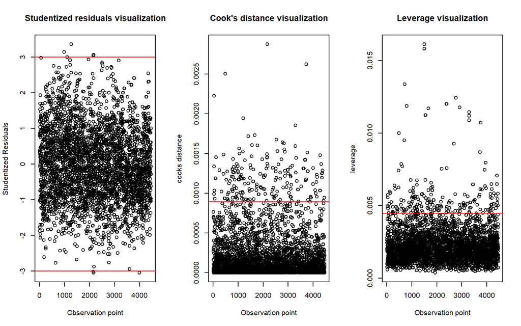

```r
# studentized residuals

studentized_residuals_best_model_9<-studres(best_model_9)

# cooks distance

cd_best_model_9<-cooks.distance(best_model_9)

# leverage

hat_values_best_model_9<-hatvalues(best_model_9)

# plot for visualization

par(mfrow=c(1,3))

plot(studentized_residuals_best_model_9, main="Studentized residuals visualization", ylab="Studentized Residuals",xlab="Observation point")
abline(h=3,col="red")
abline(h=-3,col="red")

plot(cd_best_model_9, main="Cook's distance visualization", ylab="cooks distance",xlab="Observation point")
abline(h = 4/(nrow(updated_Dataset)), col = "red")

plot(hat_values_best_model_9, main="Leverage visualization",ylab="leverage", xlab="Observation point")
abline(h= 2 * (length(best_model_9$coefficients)) / nrow(updated_Dataset),col ="red")
```

```r
high_studentized_residual_points_2<-which(studentized_residuals_best_model_9>(abs(3)))
high_leverage_points_2<-which(hat_values_best_model_9>(2*(length(best_model_9$coefficients))/nrow(updated_Dataset)))
high_cooks_distance_points_2<-which(cd_best_model_9>(4/nrow(updated_Dataset)))

all_potential_issues_2<-unique(c(high_studentized_residual_points_2,high_leverage_points_2,high_cooks_distance_points_2))

# create finalized dataset

finalized_Dataset<-updated_Dataset[-all_potential_issues_2, ]

# fitting finalized best model

finalized_best_model<-lm(quality~alcohol + volatile.acidity + residual.sugar + free.sulfur.dioxide + pH +  sulphates + density + fixed.acidity + chlorides,data=finalized_Dataset)
finalized_full_model<-lm(quality~.,data=finalized_Dataset)

str(finalized_Dataset)
summary(finalized_best_model)
```

```
## 'data.frame':    4025 obs. of  12 variables:
##  $ fixed.acidity       : num  7 6.3 8.1 7.2 7.2 8.1 6.2 7 6.3 8.1 ...
##  $ volatile.acidity    : num  0.27 0.3 0.28 0.23 0.23 0.28 0.32 0.27 0.3 0.22 ...
##  $ citric.acid         : num  0.36 0.34 0.4 0.32 0.32 0.4 0.16 0.36 0.34 0.43 ...
##  $ residual.sugar      : num  20.7 1.6 6.9 8.5 8.5 6.9 7 20.7 1.6 1.5 ...
##  $ chlorides           : num  0.045 0.049 0.05 0.058 0.058 0.05 0.045 0.045 0.049 0.044 ...
##  $ free.sulfur.dioxide : num  45 14 30 47 47 30 30 45 14 28 ...
##  $ total.sulfur.dioxide: num  170 132 97 186 186 97 136 170 132 129 ...
##  $ density             : num  1.001 0.994 0.995 0.996 0.996 ...
##  $ pH                  : num  3 3.3 3.26 3.19 3.19 3.26 3.18 3 3.3 3.22 ...
##  $ sulphates           : num  0.45 0.49 0.44 0.4 0.4 0.44 0.47 0.45 0.49 0.45 ...
##  $ alcohol             : num  8.8 9.5 10.1 9.9 9.9 10.1 9.6 8.8 9.5 11 ...
##  $ quality             : int  6 6 6 6 6 6 6 6 6 6 ...
##
## Call:
## lm(formula = quality ~ alcohol + volatile.acidity + residual.sugar +
##     free.sulfur.dioxide + pH + sulphates + density + fixed.acidity +
##     chlorides, data = finalized_Dataset)
##
## Residuals:
##      Min       1Q   Median       3Q      Max
## -1.82796 -0.44728 -0.03295  0.43411  1.81323
##
## Coefficients:
##                         Estimate   Std. Error t value           Pr(>|t|)
## (Intercept)          205.6980507   22.6036111   9.100            < 2e-16 ***
## alcohol                0.1103980    0.0286650   3.851           0.000119 ***
## volatile.acidity      -1.6708200    0.1179816 -14.162            < 2e-16 ***
## residual.sugar         0.0923997    0.0084717  10.907            < 2e-16 ***
## free.sulfur.dioxide    0.0043974    0.0006704   6.560 0.0000000000607736 ***
## pH                     1.1097245    0.1071075  10.361            < 2e-16 ***
## sulphates              0.7512165    0.0974882   7.706 0.0000000000000163 ***
## density             -207.2098617   22.9063769  -9.046            < 2e-16 ***
## fixed.acidity          0.1446669    0.0225925   6.403 0.0000000001695433 ***
## chlorides             -4.7363543    1.1195804  -4.230 0.0000238403825246 ***
## ---
## Signif. codes:  0 '***' 0.001 '**' 0.01 '*' 0.05 '.' 0.1 ' ' 1
##
## Residual standard error: 0.5863 on 4015 degrees of freedom
## Multiple R-squared:  0.3746, Adjusted R-squared:  0.3732
## F-statistic: 267.2 on 9 and 4015 DF,  p-value: < 2.2e-16
```

```r
# comparing initial best model with finalized model

Residual_standard_error_finalized_best_model<-summary(finalized_best_model)$sigma
R_squared_finalized_best_model<-summary(finalized_best_model)$r.squared
finalized_best_model_AIC<-AIC(finalized_best_model)
finalized_best_model_BIC<-BIC(finalized_best_model)
ols_finalized_best_model<-ols_mallows_cp(finalized_best_model,finalized_full_model)

# constructing the table

table_8 <- data.frame(
  Metrics = c("AIC", "BIC", "R-squared", "Residual standard error", "Mallows Cp"),
  initial_best_model = c(best_model_9_AIC, best_model_9_BIC, R_squared_best_model_9, Residual_standard_error_best_model_9,ols_best_model_9),

 finalized_best_model = c(finalized_best_model_AIC, finalized_best_model_BIC, R_squared_finalized_best_model, Residual_standard_error_finalized_best_model,ols_finalized_best_model))

# formatting the table

table_8$initial_best_model <- format(table_8$initial_best_model, digits = 5)
table_8$finalized_best_model <- format(table_8$finalized_best_model, digits = 5)

# displaying the table

table_8
```

```
##                   Metrics initial_best_model finalized_best_model
## 1                     AIC         8884.09726           7135.99331
## 2                     BIC         8954.55384           7205.29640
## 3               R-squared            0.32723              0.37456
## 4 Residual standard error            0.65277              0.58627
## 5              Mallows Cp            9.18884             11.72388
```

**INTERPRETATION**

Initially, our best model had a Mallows’ $Cp$ value of 9.18, which is close to the ideal value of 10. After removing the influential points and recalculating, the $Cp$ value changed to 11.72. Although this new value is slightly farther from the ideal value of 10, it remains relatively close. Importantly, when examining other metrics, the updated model shows a clear improvement: the AIC and BIC values are lower, indicating a better balance between model fit and complexity; and additionally the R-squared value is higher alongside a smaller residual standard error value.These improvements in key performance indicators justify that the updated model, despite the slight increase in the $Cp$ value, is overall more robust and accurate, making it the better choice.

#### VERIFICATION OF RESULTS

Now that we have identified our best model, we can make further investigation and verification using inbuilt functions designed for model selection. Specifically, we will utilize forward stepwise selection, backward stepwise selection, all-subsets regression (also known as all possible subsets or best subsets regression) and the best subsets regression. By comparing our manually selected best model with those identified by these automated procedures, we can validate our findings and ensure that we have indeed chosen the most accurate and efficient model.

```r
# fitting null model necessary for the following model selection techniques

nullmodel<-lm(quality~1,data=updated_Dataset)
summary(nullmodel)
```

```
##
## Call:
## lm(formula = quality ~ 1, data = updated_Dataset)
##
## Residuals:
##    Min     1Q Median     3Q    Max
## -1.892 -0.892  0.108  0.108  2.108
##
## Coefficients:
##             Estimate Std. Error t value Pr(>|t|)
## (Intercept)  5.89195    0.01189   495.5   <2e-16 ***
## ---
## Signif. codes:  0 '***' 0.001 '**' 0.01 '*' 0.05 '.' 0.1 ' ' 1
##
## Residual standard error: 0.795 on 4469 degrees of freedom
```

```r
# Using all subsets selection

best_step_model<-step(nullmodel,scope=list(lower=nullmodel, upper=updated_full_model,direction = "both"))
summary(best_step_model)
```

```
## Start:  AIC=-2049.49
## quality ~ 1
##
##                        Df Sum of Sq    RSS     AIC
## + alcohol               1    675.07 2149.7 -3268.2
## + density               1    363.49 2461.3 -2663.2
## + chlorides             1    264.87 2559.9 -2487.6
## + total.sulfur.dioxide  1    134.29 2690.5 -2265.2
## + volatile.acidity      1     90.73 2734.1 -2193.4
## + residual.sugar        1     58.39 2766.4 -2140.9
## + pH                    1     34.45 2790.4 -2102.3
## + fixed.acidity         1     28.87 2795.9 -2093.4
## + sulphates             1      6.10 2818.7 -2057.2
## <none>                              2824.8 -2049.5
## + free.sulfur.dioxide   1      0.38 2824.4 -2048.1
## + citric.acid           1      0.06 2824.8 -2047.6
##
## Step:  AIC=-3268.23
## quality ~ alcohol
##
##                        Df Sum of Sq    RSS     AIC
## + volatile.acidity      1    119.58 2030.2 -3522.1
## + free.sulfur.dioxide   1     41.21 2108.5 -3352.7
## + residual.sugar        1     33.97 2115.8 -3337.4
## + chlorides             1     17.12 2132.6 -3302.0
## + sulphates             1     14.25 2135.5 -3296.0
## + density               1     14.02 2135.7 -3295.5
## + pH                    1     10.30 2139.4 -3287.7
## + fixed.acidity         1      6.77 2143.0 -3280.3
## + citric.acid           1      2.64 2147.1 -3271.7
## <none>                              2149.7 -3268.2
## + total.sulfur.dioxide  1      0.30 2149.4 -3266.9
## - alcohol               1    675.07 2824.8 -2049.5
##
## Step:  AIC=-3522.07
## quality ~ alcohol + volatile.acidity
##
##                        Df Sum of Sq    RSS     AIC
## + residual.sugar        1     51.06 1979.1 -3633.9
## + free.sulfur.dioxide   1     33.04 1997.1 -3593.4
```

[output cut: 147 more lines]

```
## alcohol                0.145369    0.028224   5.151 2.71e-07 ***
## volatile.acidity      -1.798684    0.114087 -15.766  < 2e-16 ***
## residual.sugar         0.088465    0.008328  10.622  < 2e-16 ***
## free.sulfur.dioxide    0.003615    0.000684   5.285 1.32e-07 ***
## pH                     0.870439    0.106591   8.166 4.11e-16 ***
## density             -183.016739   22.401078  -8.170 3.98e-16 ***
## sulphates              0.693724    0.099592   6.966 3.75e-12 ***
## fixed.acidity          0.114772    0.022615   5.075 4.03e-07 ***
## chlorides             -2.976533    0.924643  -3.219   0.0013 **
## ---
## Signif. codes:  0 '***' 0.001 '**' 0.01 '*' 0.05 '.' 0.1 ' ' 1
##
## Residual standard error: 0.6528 on 4460 degrees of freedom
## Multiple R-squared:  0.3272, Adjusted R-squared:  0.3259
## F-statistic:   241 on 9 and 4460 DF,  p-value: < 2.2e-16
```

```r
# Using forward stepwise selction

forward_model<-step(nullmodel,scope=list(lower=nullmodel,upper=updated_full_model,direction="forward"))
summary(forward_model)
```

```
## Start:  AIC=-2049.49
## quality ~ 1
##
##                        Df Sum of Sq    RSS     AIC
## + alcohol               1    675.07 2149.7 -3268.2
## + density               1    363.49 2461.3 -2663.2
## + chlorides             1    264.87 2559.9 -2487.6
## + total.sulfur.dioxide  1    134.29 2690.5 -2265.2
## + volatile.acidity      1     90.73 2734.1 -2193.4
## + residual.sugar        1     58.39 2766.4 -2140.9
## + pH                    1     34.45 2790.4 -2102.3
## + fixed.acidity         1     28.87 2795.9 -2093.4
## + sulphates             1      6.10 2818.7 -2057.2
## <none>                              2824.8 -2049.5
## + free.sulfur.dioxide   1      0.38 2824.4 -2048.1
## + citric.acid           1      0.06 2824.8 -2047.6
##
## Step:  AIC=-3268.23
## quality ~ alcohol
##
##                        Df Sum of Sq    RSS     AIC
## + volatile.acidity      1    119.58 2030.2 -3522.1
## + free.sulfur.dioxide   1     41.21 2108.5 -3352.7
## + residual.sugar        1     33.97 2115.8 -3337.4
## + chlorides             1     17.12 2132.6 -3302.0
## + sulphates             1     14.25 2135.5 -3296.0
## + density               1     14.02 2135.7 -3295.5
## + pH                    1     10.30 2139.4 -3287.7
## + fixed.acidity         1      6.77 2143.0 -3280.3
## + citric.acid           1      2.64 2147.1 -3271.7
## <none>                              2149.7 -3268.2
## + total.sulfur.dioxide  1      0.30 2149.4 -3266.9
## - alcohol               1    675.07 2824.8 -2049.5
##
## Step:  AIC=-3522.07
## quality ~ alcohol + volatile.acidity
##
##                        Df Sum of Sq    RSS     AIC
## + residual.sugar        1     51.06 1979.1 -3633.9
## + free.sulfur.dioxide   1     33.04 1997.1 -3593.4
```

[output cut: 147 more lines]

```
## alcohol                0.145369    0.028224   5.151 2.71e-07 ***
## volatile.acidity      -1.798684    0.114087 -15.766  < 2e-16 ***
## residual.sugar         0.088465    0.008328  10.622  < 2e-16 ***
## free.sulfur.dioxide    0.003615    0.000684   5.285 1.32e-07 ***
## pH                     0.870439    0.106591   8.166 4.11e-16 ***
## density             -183.016739   22.401078  -8.170 3.98e-16 ***
## sulphates              0.693724    0.099592   6.966 3.75e-12 ***
## fixed.acidity          0.114772    0.022615   5.075 4.03e-07 ***
## chlorides             -2.976533    0.924643  -3.219   0.0013 **
## ---
## Signif. codes:  0 '***' 0.001 '**' 0.01 '*' 0.05 '.' 0.1 ' ' 1
##
## Residual standard error: 0.6528 on 4460 degrees of freedom
## Multiple R-squared:  0.3272, Adjusted R-squared:  0.3259
## F-statistic:   241 on 9 and 4460 DF,  p-value: < 2.2e-16
```

**BACKWARD STEPWISE SELECTION**

```r
# Using forward stepwise selction

backward_model<-step(updated_full_model,direction = "backward")
summary(backward_model)
```

```
## Start:  AIC=-3800.41
## quality ~ fixed.acidity + volatile.acidity + citric.acid + residual.sugar +
##     chlorides + free.sulfur.dioxide + total.sulfur.dioxide +
##     density + pH + sulphates + alcohol
##
##                        Df Sum of Sq    RSS     AIC
## - citric.acid           1     0.182 1900.1 -3802.0
## - total.sulfur.dioxide  1     0.342 1900.3 -3801.6
## <none>                              1899.9 -3800.4
## - chlorides             1     4.214 1904.1 -3792.5
## - free.sulfur.dioxide   1     9.513 1909.4 -3780.1
## - fixed.acidity         1    10.031 1910.0 -3778.9
## - alcohol               1    11.251 1911.2 -3776.0
## - sulphates             1    20.646 1920.6 -3754.1
## - density               1    24.910 1924.8 -3744.2
## - pH                    1    27.610 1927.5 -3737.9
## - residual.sugar        1    43.883 1943.8 -3700.3
## - volatile.acidity      1    94.306 1994.2 -3585.9
##
## Step:  AIC=-3801.98
## quality ~ fixed.acidity + volatile.acidity + residual.sugar +
##     chlorides + free.sulfur.dioxide + total.sulfur.dioxide +
##     density + pH + sulphates + alcohol
##
##                        Df Sum of Sq    RSS     AIC
## - total.sulfur.dioxide  1     0.324 1900.4 -3803.2
## <none>                              1900.1 -3802.0
## - chlorides             1     4.298 1904.4 -3793.9
## - free.sulfur.dioxide   1     9.670 1909.8 -3781.3
## - fixed.acidity         1    10.310 1910.4 -3779.8
## - alcohol               1    11.627 1911.7 -3776.7
## - sulphates             1    20.788 1920.9 -3755.3
## - density               1    24.728 1924.8 -3746.2
## - pH                    1    27.437 1927.5 -3739.9
## - residual.sugar        1    43.706 1943.8 -3702.3
## - volatile.acidity      1    97.856 1998.0 -3579.5
##
## Step:  AIC=-3803.21
## quality ~ fixed.acidity + volatile.acidity + residual.sugar +
##     chlorides + free.sulfur.dioxide + density + pH + sulphates +
```

[output cut: 26 more lines]

```
## fixed.acidity          0.114772    0.022615   5.075 4.03e-07 ***
## volatile.acidity      -1.798684    0.114087 -15.766  < 2e-16 ***
## residual.sugar         0.088465    0.008328  10.622  < 2e-16 ***
## chlorides             -2.976533    0.924643  -3.219   0.0013 **
## free.sulfur.dioxide    0.003615    0.000684   5.285 1.32e-07 ***
## density             -183.016739   22.401078  -8.170 3.98e-16 ***
## pH                     0.870439    0.106591   8.166 4.11e-16 ***
## sulphates              0.693724    0.099592   6.966 3.75e-12 ***
## alcohol                0.145369    0.028224   5.151 2.71e-07 ***
## ---
## Signif. codes:  0 '***' 0.001 '**' 0.01 '*' 0.05 '.' 0.1 ' ' 1
##
## Residual standard error: 0.6528 on 4460 degrees of freedom
## Multiple R-squared:  0.3272, Adjusted R-squared:  0.3259
## F-statistic:   241 on 9 and 4460 DF,  p-value: < 2.2e-16
```

**BEST SUBSETS REGRESSION**

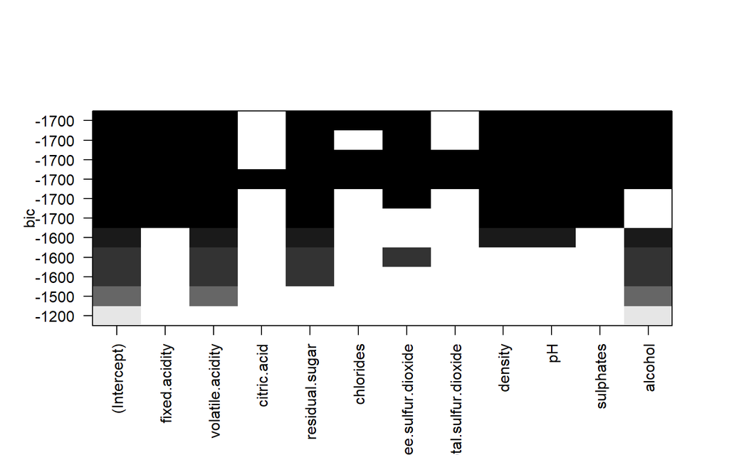

```
## Subset selection object
## Call: regsubsets.formula(quality ~ ., data = updated_Dataset, nbest = 1,
##     nvmax = 11)
## 11 Variables  (and intercept)
##                      Forced in Forced out
## fixed.acidity            FALSE      FALSE
## volatile.acidity         FALSE      FALSE
## citric.acid              FALSE      FALSE
## residual.sugar           FALSE      FALSE
## chlorides                FALSE      FALSE
## free.sulfur.dioxide      FALSE      FALSE
## total.sulfur.dioxide     FALSE      FALSE
## density                  FALSE      FALSE
## pH                       FALSE      FALSE
## sulphates                FALSE      FALSE
## alcohol                  FALSE      FALSE
## 1 subsets of each size up to 11
## Selection Algorithm: exhaustive
##           fixed.acidity volatile.acidity citric.acid residual.sugar chlorides
## 1  ( 1 )  " "           " "              " "         " "            " "
## 2  ( 1 )  " "           "*"              " "         " "            " "
## 3  ( 1 )  " "           "*"              " "         "*"            " "
## 4  ( 1 )  " "           "*"              " "         "*"            " "
## 5  ( 1 )  " "           "*"              " "         "*"            " "
## 6  ( 1 )  "*"           "*"              " "         "*"            " "
## 7  ( 1 )  "*"           "*"              " "         "*"            " "
## 8  ( 1 )  "*"           "*"              " "         "*"            " "
## 9  ( 1 )  "*"           "*"              " "         "*"            "*"
## 10  ( 1 ) "*"           "*"              " "         "*"            "*"
## 11  ( 1 ) "*"           "*"              "*"         "*"            "*"
##           free.sulfur.dioxide total.sulfur.dioxide density pH  sulphates
## 1  ( 1 )  " "                 " "                  " "     " " " "
## 2  ( 1 )  " "                 " "                  " "     " " " "
## 3  ( 1 )  " "                 " "                  " "     " " " "
## 4  ( 1 )  "*"                 " "                  " "     " " " "
## 5  ( 1 )  " "                 " "                  "*"     "*" " "
## 6  ( 1 )  " "                 " "                  "*"     "*" "*"
## 7  ( 1 )  "*"                 " "                  "*"     "*" "*"
## 8  ( 1 )  "*"                 " "                  "*"     "*" "*"
## 9  ( 1 )  "*"                 " "                  "*"     "*" "*"
## 10  ( 1 ) "*"                 "*"                  "*"     "*" "*"
## 11  ( 1 ) "*"                 "*"                  "*"     "*" "*"
##           alcohol
## 1  ( 1 )  "*"
## 2  ( 1 )  "*"
## 3  ( 1 )  "*"
## 4  ( 1 )  "*"
## 5  ( 1 )  "*"
## 6  ( 1 )  " "
## 7  ( 1 )  " "
## 8  ( 1 )  "*"
## 9  ( 1 )  "*"
## 10  ( 1 ) "*"
## 11  ( 1 ) "*"
```

```r
# Using Best Subsets Regression

best_subsets_model<-regsubsets(quality~.,data=updated_Dataset, nbest=1,nvmax=11)
summary(best_subsets_model)
plot(best_subsets_model)
```

**INTERPRETATION**

After conducting best subsets regression and stepwise regression, we found that all results interestingly enough produced the same best model as our previously identified one. Both methods systematically evaluated different combinations of predictors and, despite their different approaches, consistently pointed to the same model as the optimal choice. This convergence of results allows for a greater confidence in the accuracy and effectiveness of our final best model.